# Newspaper coverage of wars in the 21st century

# Comparison

## Distribution

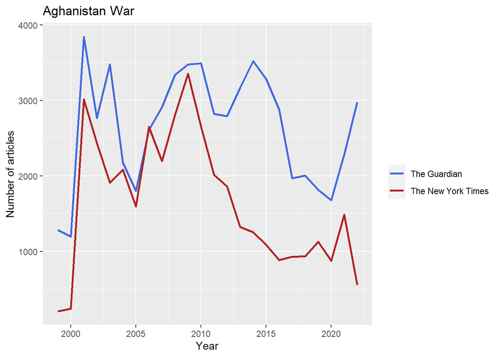

```r
afgh_year_total <- afgh[!duplicated(afgh[ , c("year")]), ] %>%
  select(total_year, year)

syria_year_total <- syria[!duplicated(syria[ , c("year")]), ] %>%
  select(total_year, year)

ukraine_year_total <- ukraine[!duplicated(ukraine[ , c("year")]), ] %>%
  select(total_year, year)

nyt_afgh_year_total <- nyt_afgh[!duplicated(nyt_afgh[ , c("year")]), ] %>%
  select(hits_year, year)

nyt_syria_year_total <- nyt_syria[!duplicated(nyt_syria[ , c("year")]), ] %>%
  select(hits_year, year)

nyt_ukraine_year_total <- nyt_ukraine[!duplicated(nyt_ukraine[ , c("year")]), ] %>%
  select(hits_year, year)

afgh_dist_plot <- ggplot()+
  geom_line(afgh_year_total,
            mapping = aes(x=year, y=total_year,
                          color="The Guardian"), size=1)+
  geom_line(nyt_afgh_year_total,
            mapping = aes(x=year, y=hits_year,
                          color="The New York Times"), size=1)+
  scale_color_manual("",
                     values = c("The Guardian"="royalblue",
                                "The New York Times"="firebrick"))+
  labs(title="Aghanistan War", x="Year", y="Number of articles")
afgh_dist_plot
```

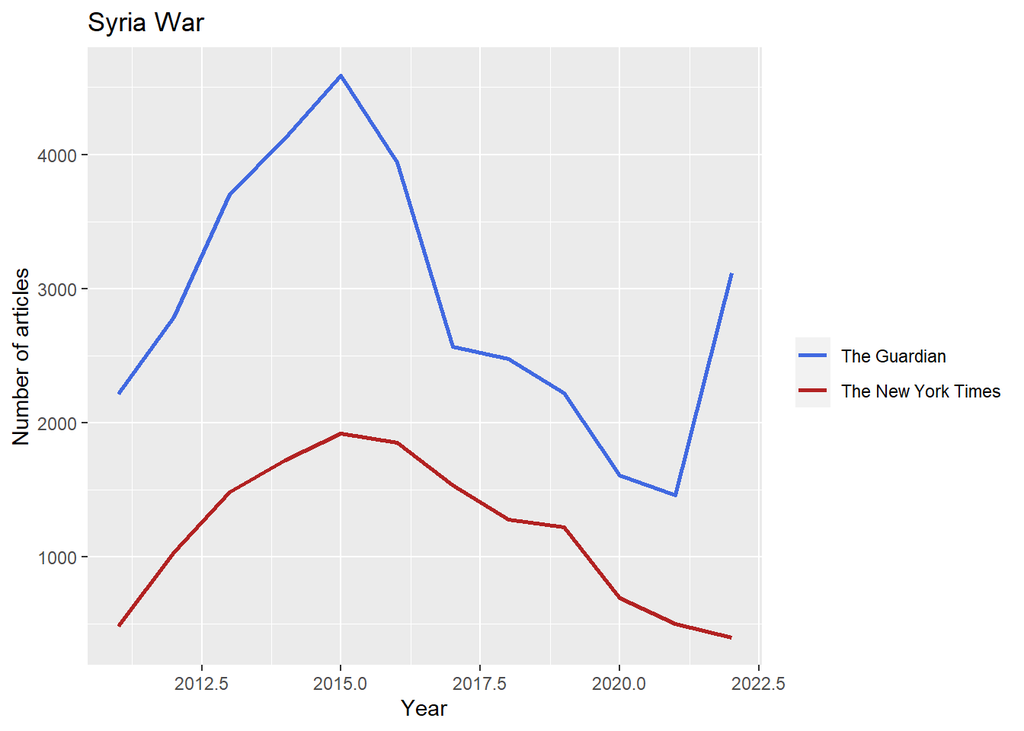

```r
syria_dist_plot <- ggplot()+
  geom_line(syria_year_total,
            mapping = aes(x=year, y=total_year,
                          color="The Guardian"), size=1)+
  geom_line(nyt_syria_year_total,
            mapping = aes(x=year, y=hits_year,
                          color="The New York Times"), size=1)+
  scale_color_manual("",
                     values = c("The Guardian"="royalblue",
                                "The New York Times"="firebrick"))+
  labs(title="Syria War", x="Year", y="Number of articles")
syria_dist_plot
```

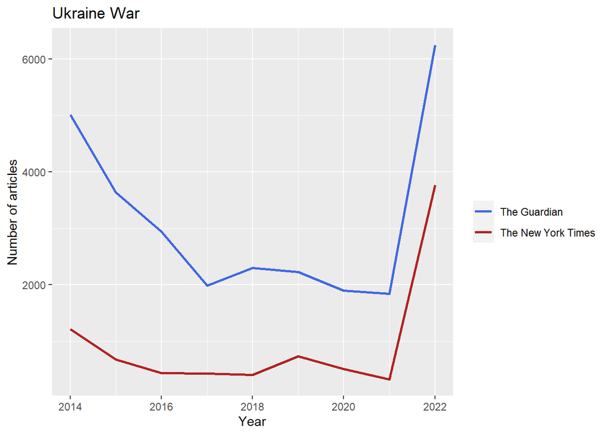

```r
ukraine_dist_plot <- ggplot()+
  geom_line(ukraine_year_total,
            mapping = aes(x=year, y=total_year,
                          color="The Guardian"), size=1)+
  geom_line(nyt_ukraine_year_total,
            mapping = aes(x=year, y=hits_year,
                          color="The New York Times"), size=1)+
  scale_color_manual("",
                     values = c("The Guardian"="royalblue",
                                "The New York Times"="firebrick"))+
  labs(title="Ukraine War", x="Year", y="Number of articles")
ukraine_dist_plot
```

By looking at the distribution of the articles the first noticeable difference between the two newspaper is that the Guardian published more articles almost in every year about every war. But the distance between the two newspaper varies a lot. When comparing the war in Afghanistan and the war in Ukraine it is clearly visible that the difference in the number of published articles is a lot smaller in the Afghanistan war and a lot larger in the Ukraine war. This makes sense since the origin country of the New York Times was involved in the war and the origin country of the Guardian is geographically and politically much closer to the Ukraine. Another noticeable difference is that the number of articles published for the war in Syria peaks again in 2022 in the Guardian but there’s no sign of that in the New York Times.

## Sentiment Analysis

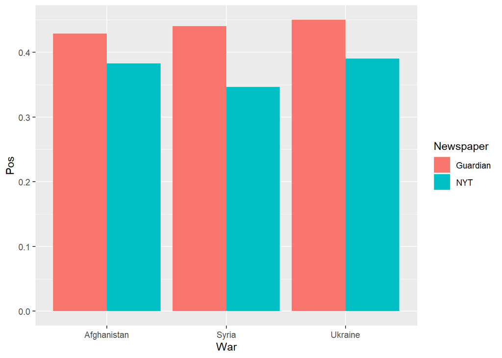

```r
sent_comparison <- data.frame(matrix(nrow = 6, ncol = 3))
colnames(sent_comparison) <- c("Newspaper", "War", "Pos")
sent_comparison$Newspaper <- c("Guardian", "Guardian", "Guardian", "NYT", "NYT", "NYT")
sent_comparison$War <- c("Afghanistan", "Syria", "Ukraine", "Afghanistan", "Syria", "Ukraine")
sent_comparison$Pos <- c(mean(afgh_sent$pos_neg),
                         mean(syria_sent$pos_neg),
                         mean(ukraine_sent$pos_neg),
                         mean(nyt_afgh_sent$pos_neg),
                         mean(nyt_syria_sent$pos_neg),
                         mean(nyt_ukraine_sent$pos_neg))

# sent_comparison

comp_sent_plot <- sent_comparison %>%
  ggplot(aes(x=War, y=Pos, fill = Newspaper))+
  geom_bar(position = "dodge", stat="identity")
comp_sent_plot
```

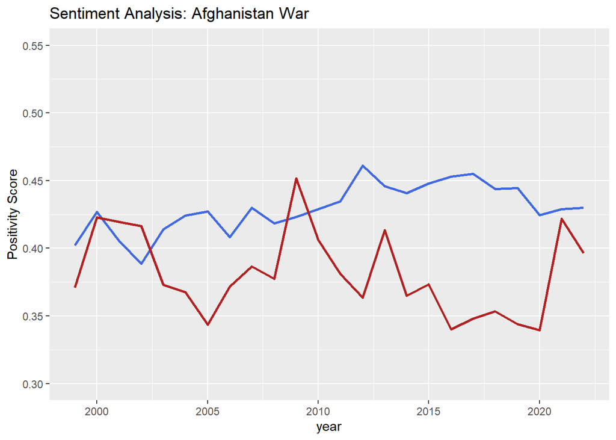

```r
afgh_sent_plot <- ggplot()+
  geom_line(afgh_by_year, mapping = aes(x=year, y=pos_neg), size = 1, color = "royalblue")+
  geom_line(nyt_afgh_by_year, mapping = aes(x=year, y=pos_neg, group=1), size = 1, color = "firebrick")+
  ylim(0.3, 0.55)+
  labs(title = "Sentiment Analysis: Afghanistan War", y="Positivity Score")
afgh_sent_plot
```

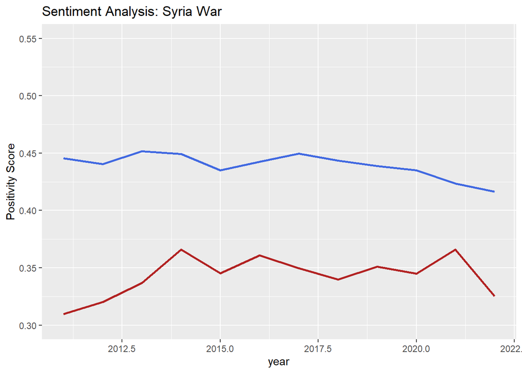

```r
syria_sent_plot <- ggplot()+
  geom_line(syria_by_year, mapping = aes(x=year, y=pos_neg), size = 1, color = "royalblue")+
  geom_line(nyt_syria_by_year, mapping = aes(x=as.numeric(year), y=pos_neg, group=1), size = 1, color = "firebrick")+
  ylim(0.3, 0.55)+
  labs(title = "Sentiment Analysis: Syria War", y="Positivity Score")
syria_sent_plot
```

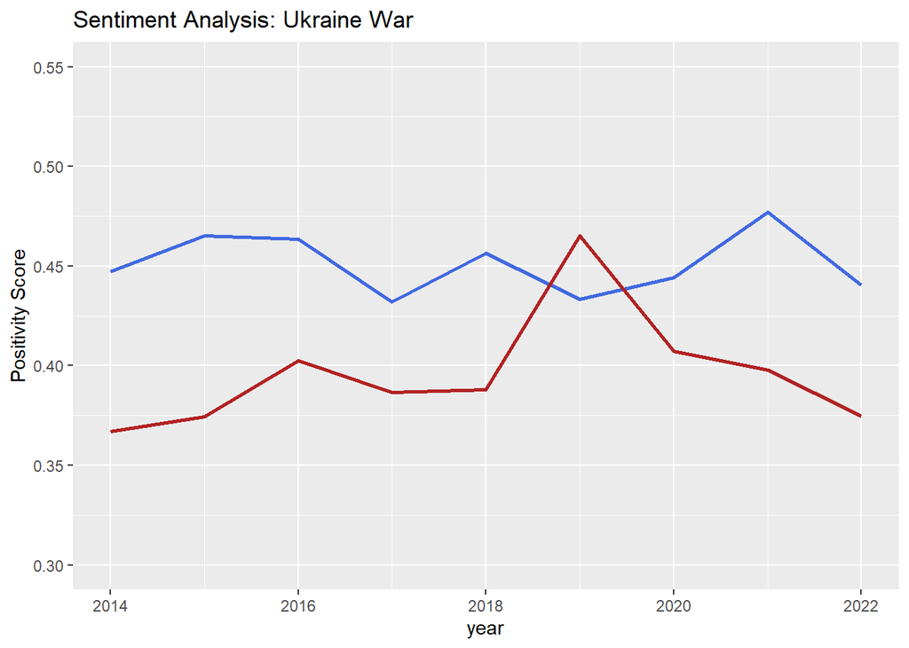

```r
ukraine_sent_plot <- ggplot()+
  geom_line(ukraine_by_year, mapping = aes(x=year, y=pos_neg), size = 1, color = "royalblue")+
  geom_line(nyt_ukraine_by_year, mapping = aes(x=year, y=pos_neg, group=1), size = 1, color = "firebrick")+
  ylim(0.3, 0.55)+
  labs(title = "Sentiment Analysis: Ukraine War", y="Positivity Score")
ukraine_sent_plot
```

In general one can say that the Guardian has a more positive broadcasting style then the New York Times. This is consistent over all the wars and only in certain years has the New York Times a higher average Sentiment score than the Guardian. But it is noticeable that the difference is larger and even more consistent in the war in Syria. In comparison, in the Afghanistan war (in which the USA was the leading party) the New York Times has in three years a higher positivity score than the Guardian and also the fluctuation is very high. The difference between the newspapers could be a result of a broadcasting style or also of political agendas. The results from the New york Times suggests that there is something to further look into. But the differences could also be the result of language norms in the two different countries.

## Word Frequency

```r
load("Data/afgh_dfm.RData")
load("Data/syria_dfm.RData")
load("Data/ukraine_dfm.RData")
load("Data/nyt_afgh_dfm.RData")
load("Data/nyt_syria_dfm.RData")
load("Data/nyt_ukraine_dfm.RData")
```

#### Afghanistan

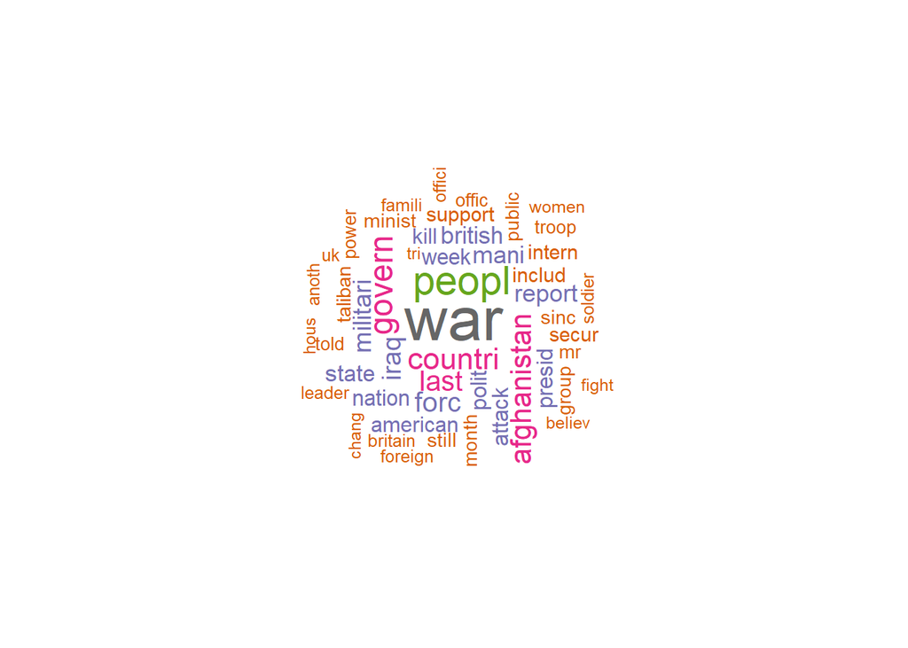

```r
afgh_textplot <- textplot_wordcloud(afgh_dfm,
                   max_words = 50,
                   random_order = FALSE,
                   rotation = .3,
                   color = RColorBrewer::brewer.pal(8, "Dark2"))
```

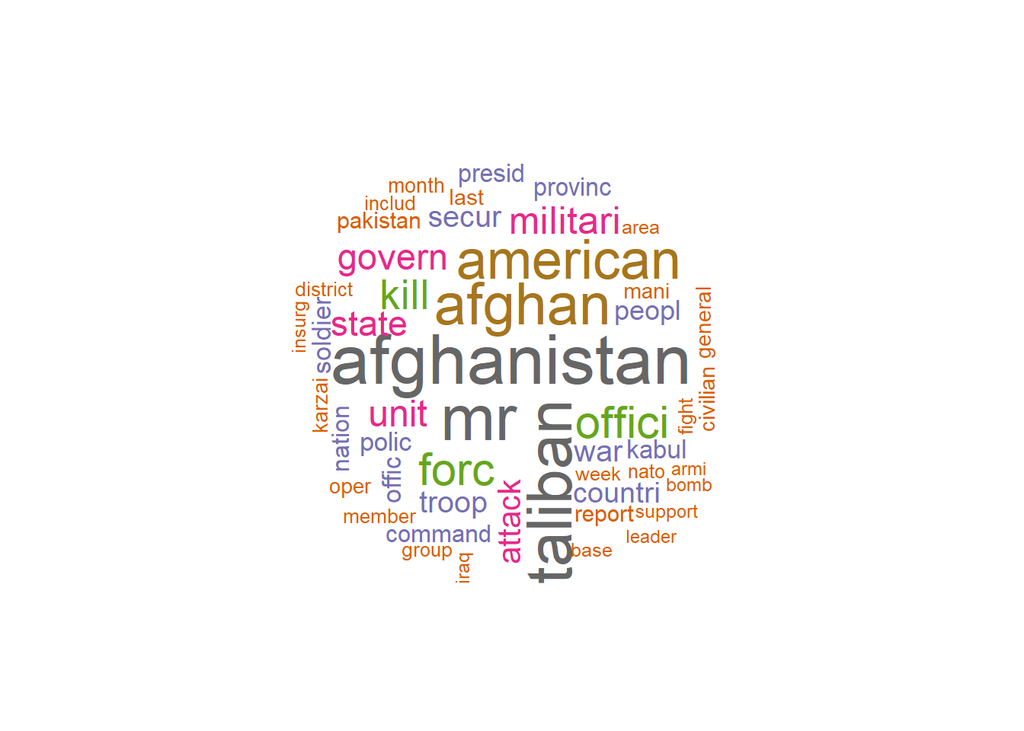

```r
nyt_afgh_textplot <- textplot_wordcloud(nyt_afgh_dfm,
                   max_words = 50,
                   random_order = FALSE,
                   rotation = .3,
                   color = RColorBrewer::brewer.pal(8, "Dark2"))
```

Here is a clear difference noticeable between the two newspapers. The New York Times uses the words “Afghanistan” and especially “Taliban” much more often then the Guardian. This is to be expected since the USA (the origin country of the New York Times) began the war in Afghanistan after the 9/11 terrorist attack executed by the Taliban. This led to the Taliban being the concept of the enemy.

#### Syria

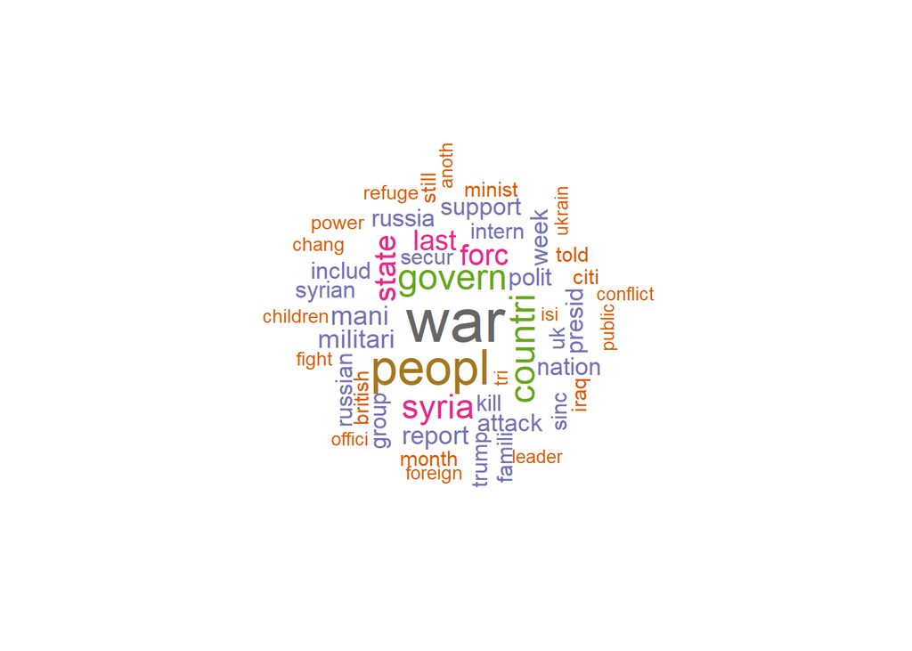

```r
syria_textplot <- textplot_wordcloud(syria_dfm,
                   max_words = 50,
                   random_order = FALSE,
                   rotation = .3,
                   color = RColorBrewer::brewer.pal(8, "Dark2"))
```

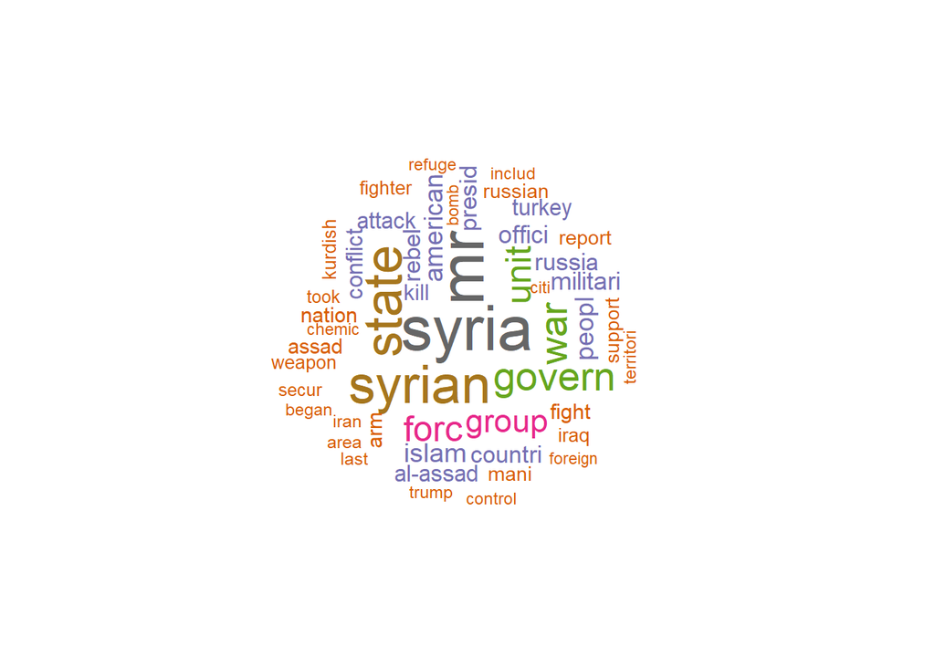

```r
nyt_syria_textplot <- textplot_wordcloud(nyt_syria_dfm,
                   max_words = 50,
                   random_order = FALSE,
                   rotation = .3,
                   color = RColorBrewer::brewer.pal(8, "Dark2"))
```

There are no real notable differences between the newspapers visible.

#### Ukraine

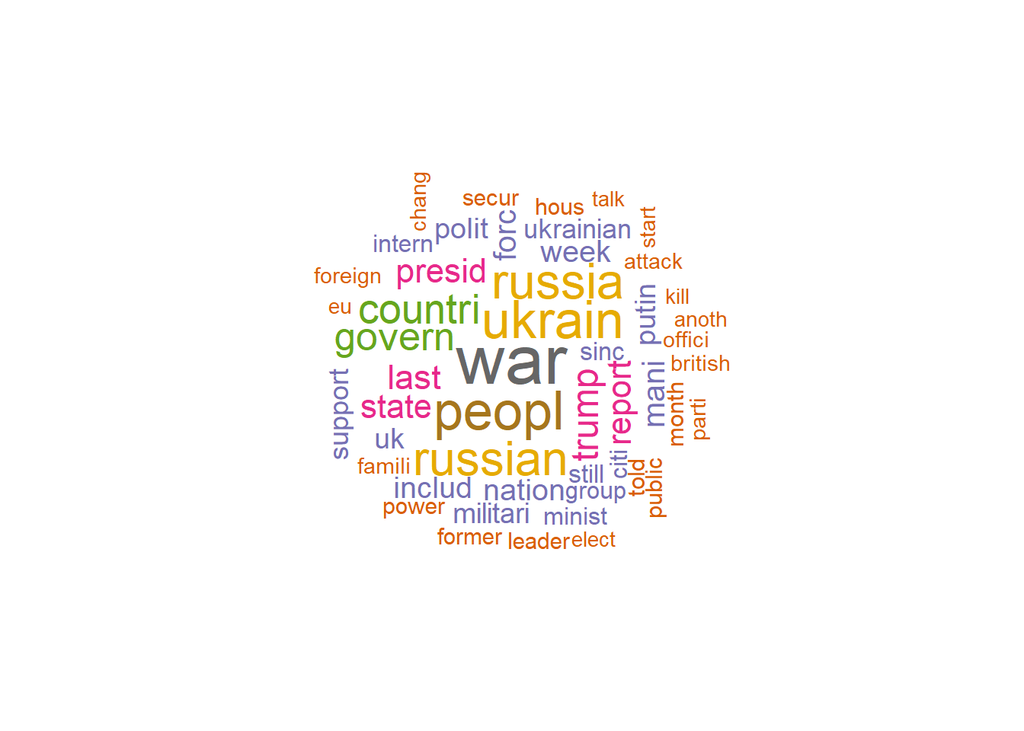

```r
ukraine_textplot <- textplot_wordcloud(ukraine_dfm,
                   max_words = 50,
                   random_order = FALSE,
                   rotation = .3,
                   color = RColorBrewer::brewer.pal(8, "Dark2"))
```

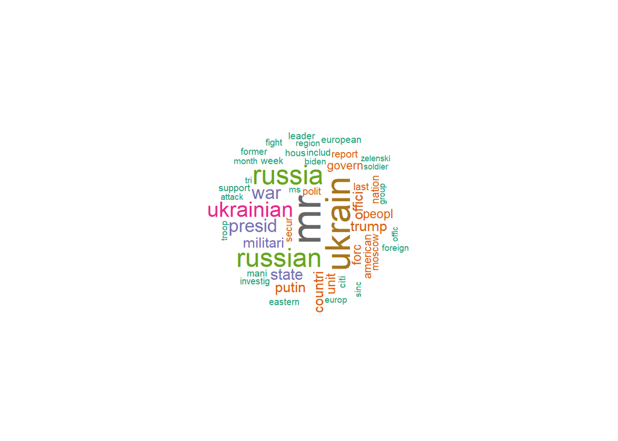

```r
nyt_ukraine_textplot <- textplot_wordcloud(nyt_ukraine_dfm,
                   max_words = 50,
                   random_order = FALSE,
                   rotation = .3,
                   color = RColorBrewer::brewer.pal(8, "Dark2"))
```

There are no real notable differences between the newspapers visible.

### Over all Word Frequencies

It is difficult here to make a general statement. The noticeable differences between the newspaper could be from the involvement of the country of origin or also from language norms. It is difficult to spot if a difference really comes from a different style of news portrayal. One consistent difference is that the Guardian uses the word “war” much more often then the New York Times. On the other hand it is noticeable that the New York Times very often uses the word “mr” which would suggest a more person-related coverage. But I would argue that that’s a result of different language norms in the UK and US.

## Policy Agendas

```r
load("Data/afgh_pol.RData")
load("Data/syria_pol.RData")
load("Data/ukraine_pol.RData")
load("Data/nyt_afgh_pol.RData")
load("Data/nyt_syria_pol.RData")
load("Data/nyt_ukraine_pol.RData")
```

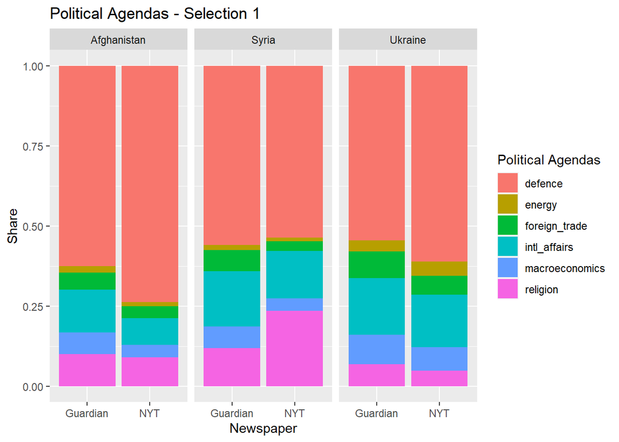

```r
afgh_pol_total <- afgh_pol %>% select(-year) %>%
  colSums(.) %>%
  enframe()
afgh_pol_total$war <- "Afghanistan"
afgh_pol_total$newspaper <- "Guardian"

syria_pol_total <- syria_pol %>% select(-year) %>%
  colSums(.) %>%
  enframe()
syria_pol_total$war <- "Syria"
syria_pol_total$newspaper <- "Guardian"

ukraine_pol_total <- ukraine_pol %>% select(-year) %>%
  colSums(.) %>%
  enframe()
ukraine_pol_total$war <- "Ukraine"
ukraine_pol_total$newspaper <- "Guardian"

nyt_afgh_pol_total <- nyt_afgh_pol %>% select(-year) %>%
  colSums(.) %>%
  enframe()
nyt_afgh_pol_total$war <- "Afghanistan"
nyt_afgh_pol_total$newspaper <- "NYT"

nyt_syria_pol_total <- nyt_syria_pol %>% select(-year) %>%
  colSums(.) %>%
  enframe()
nyt_syria_pol_total$war <- "Syria"
nyt_syria_pol_total$newspaper <- "NYT"

nyt_ukraine_pol_total <- nyt_ukraine_pol %>% select(-year) %>%
  colSums(.) %>%
  enframe()
nyt_ukraine_pol_total$war <- "Ukraine"
nyt_ukraine_pol_total$newspaper <- "NYT"

pol_total <- rbind(afgh_pol_total, syria_pol_total, ukraine_pol_total,
                   nyt_afgh_pol_total, nyt_syria_pol_total, nyt_ukraine_pol_total)


pol_total_plot <- pol_total %>%
  filter(name %in% c("defence", "energy", "foreign_trade", "intl_affairs", "macroeconomics", "religion")) %>%
  ggplot(aes(x=newspaper, y=value, fill = name))+
  geom_bar(stat = "identity",
           position = "fill")+
  facet_grid(~ war)+
  labs(title = "Political Agendas - Selection 1", y="Share", x="Newspaper")+
  scale_fill_discrete(name = "Political Agendas")
pol_total_plot
```

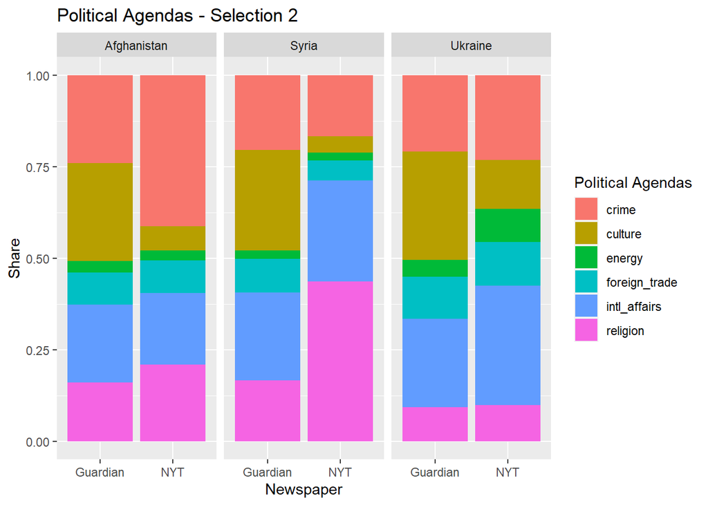

```r
pol_total_plot_2 <- pol_total %>%
  filter(name %in% c("foreign_trade", "intl_affairs", "crime", "religion", "culture", "energy")) %>%
  ggplot(aes(x=newspaper, y=value, fill = name))+
  geom_bar(stat = "identity",
           position = "fill")+
  facet_grid(~ war)+
  labs(title = "Political Agendas - Selection 2", y="Share", x="Newspaper")+
  scale_fill_discrete(name = "Political Agendas")
pol_total_plot_2
```

The comparison shows that there are some differences between the two newspapers. For the Afghanistan war the New York Times seems to concentrate much more on the “defence” part than the Guardian, the same holds for the war in Ukraine. The second selection shows probably the most consistent difference between the two: culture. Over all three wars the Guardian reports much more about the culture aspect. Other major differences are that the New York Times covers more crime in the Afghanistan war and a lot more religion in the Syrian war.

When comparing the wars there are not many clear differences. The differences get mainly concealed by the differences between the newspapers. Nevertheless there are some notable results. Defence is more covered in the Afghanistan war then in the other two, Energy seems to be more important for the war in Ukraine and religion is a larger part in the Syrian war.

# Conclusion

Over all there were some noticeable differences especially between the two newspapers. But one problem is consistent over all the analysis methods. It is very difficult to say if the differences in the result come from the differences between the two publishers or from the differences between the two origin countries. To control for that part I would need to look at other newspapers from the two countries to check how newspaper within a country differ from each other. In further research it would also be interesting to dive deeper into each one of the analysis methods. For example would it be interesting to see how the sentiment changes when filtering out articles which contain specific words like “America” or “Russia”.

Another important aspect is the data gathering. I chose to use the simple search terms “Afghanistan war”, “Syria war” and “Ukraine war”. A completely unrelated difference between the two newspapers could be in the search algorithm of their API. I don’t know how broadly they decide if an article matches a search term or not. So one newspaper could include a much broader variety of articles. Such technical differences could change the outcome of this research.

In conclusion, no real interpretive statement can be made. But this work has shown that there is something to look for and it can inspire further research to get to the bottom of the original question of this paper.